# Deep Learning Lab I (L05)

Data Science III (STAT 301-3)

May 12th, 2019

# Overview

The goal of this lab is ensure that we are able to actually fit neural networks using the `keras` and `tensorflow` packages in R. We want to ensure that we can recreate the examples in provided in Chapters 2 and 3 in *Deep Learning with R*.

When creating the Rmd file for this assignment, you won’t want all your code chunks to evaluate because it would take to long to run. You’ll want to produce results, store them in a subdirectory, and then reference them in the Rmd file. You may need to use hidden chunks of code to read in results or use Rmd code to insert graphics that you want to display. **Make sure to thoroughly comment and describe what the code is doing in our own words.**

Author provides great [notebooks on github](https://github.com/jjallaire/deep-learning-with-r-notebooks) to go along with the book.

# Datasets

All datasets are supplied by the `keras` package — `mnist`, `imdb`, `rueters`, and `boston_housing`.

# Exercises

Please complete the following exercises. The document should be neatly formatted.

#### Load Packages

```r
# Loading package(s)
library(tensorflow)
use_python("/usr/bin/python")
# install_tensorflow(version = "1.12")
library(keras)
```

#### Exercise 1

Recreate the example provided in Section 2.1 (pg 25 - 29). See the [notebook](https://jjallaire.github.io/deep-learning-with-r-notebooks/notebooks/2.1-a-first-look-at-a-neural-network.nb.html) provided by the author.

```r
# load data
mnist <- dataset_mnist()
train_images <- mnist$train$x
train_labels <- mnist$train$y
test_images <- mnist$test$x
test_labels <- mnist$test$y
# have a look at the training data
str(train_images)
```

```
##  int [1:60000, 1:28, 1:28] 0 0 0 0 0 0 0 0 0 0 ...
```

```r
str(train_labels)
```

```
##  int [1:60000(1d)] 5 0 4 1 9 2 1 3 1 4 ...
```

```r
# have a look at the test data
str(test_images)
```

```
##  int [1:10000, 1:28, 1:28] 0 0 0 0 0 0 0 0 0 0 ...
```

```r
str(test_labels)
```

```
##  int [1:10000(1d)] 7 2 1 0 4 1 4 9 5 9 ...
```

```r
# build the network
network <- keras_model_sequential() %>%
  layer_dense(units = 512, activation = "relu", input_shape = c(28 * 28)) %>%
  layer_dense(units = 10, activation = "softmax")
# pick optimizer, loss function and monitor metrics
network %>% compile(
  optimizer = "rmsprop",
  loss = "categorical_crossentropy",
  metrics = c("accuracy")
)
# reshape the data
train_images <- array_reshape(train_images, c(60000, 28 * 28))
train_images <- train_images / 255
test_images <- array_reshape(test_images, c(10000, 28 * 28))
test_images <- test_images / 255
#categorically encode the labels
train_labels <- to_categorical(train_labels)
test_labels <- to_categorical(test_labels)
# train the network
network %>% fit(train_images, train_labels, epochs = 5, batch_size = 128)
# model performance on the test set
metrics <- network %>% evaluate(test_images, test_labels, verbose = 0)
metrics
```

```
## $loss
## [1] 0.07598309
##
## $acc
## [1] 0.9775
```

Alternatively, students are welcome to work through the example provided on the [Keras in RStudio website](https://keras.rstudio.com/).

```r
# Preparing the Data
library(keras)
mnist <- dataset_mnist()
x_train <- mnist$train$x
y_train <- mnist$train$y
x_test <- mnist$test$x
y_test <- mnist$test$y
# reshape
x_train <- array_reshape(x_train, c(nrow(x_train), 784))
x_test <- array_reshape(x_test, c(nrow(x_test), 784))
# rescale
x_train <- x_train / 255
x_test <- x_test / 255
# one-hot encode the variables
y_train <- to_categorical(y_train, 10)
y_test <- to_categorical(y_test, 10)
# create a sequential model and then adding layers
model <- keras_model_sequential()
model %>%
  layer_dense(units = 256, activation = 'relu', input_shape = c(784)) %>%
  layer_dropout(rate = 0.4) %>%
  layer_dense(units = 128, activation = 'relu') %>%
  layer_dropout(rate = 0.3) %>%
  layer_dense(units = 10, activation = 'softmax')
# print the details of the model
summary(model)
```

```
## ___________________________________________________________________________
## Layer (type)                     Output Shape                  Param #
## ===========================================================================
## dense_2 (Dense)                  (None, 256)                   200960
## ___________________________________________________________________________
## dropout (Dropout)                (None, 256)                   0
## ___________________________________________________________________________
## dense_3 (Dense)                  (None, 128)                   32896
## ___________________________________________________________________________
## dropout_1 (Dropout)              (None, 128)                   0
## ___________________________________________________________________________
## dense_4 (Dense)                  (None, 10)                    1290
## ===========================================================================
## Total params: 235,146
## Trainable params: 235,146
## Non-trainable params: 0
## ___________________________________________________________________________
```

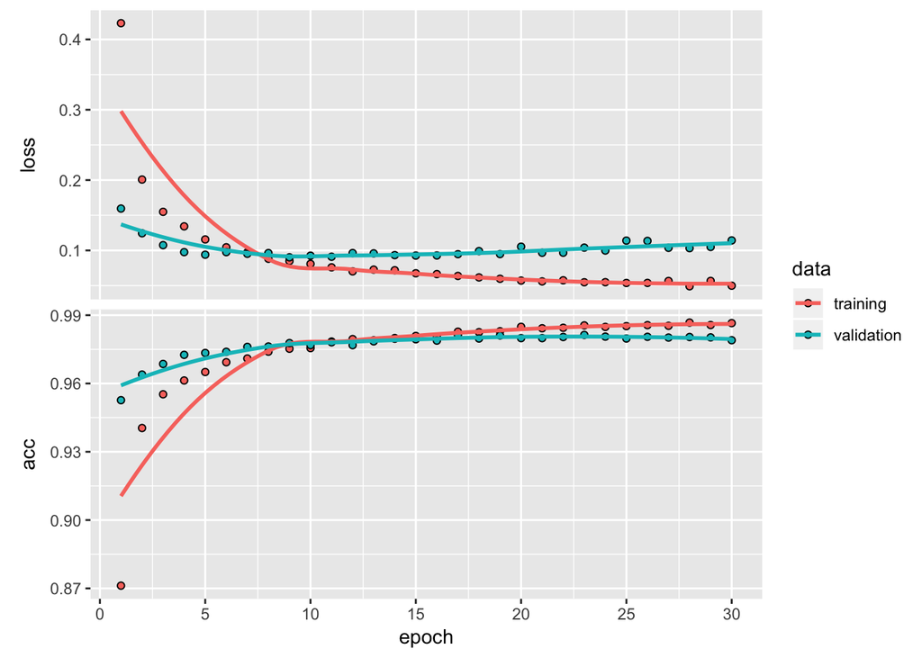

```r
# compile the model
model %>% compile(
  loss = 'categorical_crossentropy',
  optimizer = optimizer_rmsprop(),
  metrics = c('accuracy')
)
# train the model
history <- model %>% fit(
  x_train, y_train,
  epochs = 30, batch_size = 128,
  validation_split = 0.2
)
# plot object
plot(history)
```

```r
# Evaluate the model’s performance on the test data
model %>% evaluate(x_test, y_test)
```

```
## $loss
## [1] 0.1044125
##
## $acc
## [1] 0.9821
```

```r
# Generate predictions on new data
model %>% predict_classes(x_test)
```

[output not shown]

[output cut: 280 more lines]

#### Exercise 2

Recreate the example provided in Section 3.4 (pg 59 - 69). See the [notebook](https://jjallaire.github.io/deep-learning-with-r-notebooks/notebooks/3.4-classifying-movie-reviews.nb.html) provided by the author.

```r
# load the dataset
library(keras)
imdb <- dataset_imdb(num_words = 10000)
c(c(train_data, train_labels), c(test_data, test_labels)) %<-% imdb
str(train_data[[1]])
```

```
##  int [1:218] 1 14 22 16 43 530 973 1622 1385 65 ...
```

```r
train_labels[[1]]
```

```
## [1] 1
```

```r
max(sapply(train_data, max))
```

```
## [1] 9999
```

```r
# decode the reviews back to English words
# word_index is a dictionary mapping words to an integer index
word_index <- dataset_imdb_word_index()
# We reverse it, mapping integer indices to words
reverse_word_index <- names(word_index)
names(reverse_word_index) <- word_index
# We decode the review; note that our indices were offset by 3
# because 0, 1 and 2 are reserved indices for "padding", "start of sequence", and "unknown".
decoded_review <- sapply(train_data[[1]], function(index) {
  word <- if (index >= 3) reverse_word_index[[as.character(index - 3)]]
  if (!is.null(word)) word else "?"
})
cat(decoded_review)
```

```
## ? this film was just brilliant casting location scenery story direction everyone's really suited the part they played and you could just imagine being there robert ? is an amazing actor and now the same being director ? father came from the same scottish island as myself so i loved the fact there…
```

```r
# preparing the data
# turn the lists into tensors
vectorize_sequences <- function(sequences, dimension = 10000) {
  # Create an all-zero matrix of shape (len(sequences), dimension)
  results <- matrix(0, nrow = length(sequences), ncol = dimension)
  for (i in 1:length(sequences))
    # Sets specific indices of results[i] to 1s
    results[i, sequences[[i]]] <- 1
  results
}
# Our vectorized training data
x_train <- vectorize_sequences(train_data)
# Our vectorized test data
x_test <- vectorize_sequences(test_data)
str(x_train[1,])
```

```
##  num [1:10000] 1 1 0 1 1 1 1 1 1 0 ...
```

```r
# Our vectorized labels
y_train <- as.numeric(train_labels)
y_test <- as.numeric(test_labels)
```

```r
# buiding the network
model <- keras_model_sequential() %>%
  layer_dense(units = 16, activation = "relu", input_shape = c(10000)) %>%
  layer_dense(units = 16, activation = "relu") %>%
  layer_dense(units = 1, activation = "sigmoid")
model %>% compile(
  optimizer = "rmsprop",
  loss = "binary_crossentropy",
  metrics = c("accuracy")
)
# custom compile
model %>% compile(
  optimizer = optimizer_rmsprop(lr = 0.001),
  loss = loss_binary_crossentropy,
  metrics = metric_binary_accuracy
)
```

```r
# validating our approach
# set apart 10000 samples from the original training data
val_indices <- 1:10000
x_val <- x_train[val_indices,]
partial_x_train <- x_train[-val_indices,]
y_val <- y_train[val_indices]
partial_y_train <- y_train[-val_indices]
# train a new network from scratch for four epochs and then evaluate it on the test data
model <- keras_model_sequential() %>%
  layer_dense(units = 16, activation = "relu", input_shape = c(10000)) %>%
  layer_dense(units = 16, activation = "relu") %>%
  layer_dense(units = 1, activation = "sigmoid")
model %>% compile(
  optimizer = "rmsprop",
  loss = "binary_crossentropy",
  metrics = c("accuracy")
)
model %>% fit(x_train, y_train, epochs = 4, batch_size = 512)
results <- model %>% evaluate(x_test, y_test)
results
```

```
## $loss
## [1] 0.3203751
##
## $acc
## [1] 0.8728
```

```r
# using a trained network to generate predictions on new data
model %>% predict(x_test[1:10,])
```

```
##             [,1]
##  [1,] 0.18824022
##  [2,] 0.99984705
##  [3,] 0.41716751
##  [4,] 0.66543603
##  [5,] 0.93140036
##  [6,] 0.78236598
##  [7,] 0.99797350
##  [8,] 0.00663722
##  [9,] 0.97043812
## [10,] 0.98817611
```

#### Exercise 3

Recreate the example provided in Section 3.5 (pg 70 - 76). See the [notebook](https://jjallaire.github.io/deep-learning-with-r-notebooks/notebooks/3.5-classifying-newswires.nb.html) provided by the author.

```r
# load dataset
library(keras)
reuters <- dataset_reuters(num_words = 10000)
c(c(train_data, train_labels), c(test_data, test_labels)) %<-% reuters
length(train_data)
```

```
## [1] 8982
```

```r
length(test_data)
```

```
## [1] 2246
```

```r
train_data[[1]]
```

```
##  [1]    1    2    2    8   43   10  447    5   25  207  270    5 3095  111
## [15]   16  369  186   90   67    7   89    5   19  102    6   19  124   15
## [29]   90   67   84   22  482   26    7   48    4   49    8  864   39  209
## [43]  154    6  151    6   83   11   15   22  155   11   15    7   48    9
## [57] 4579 1005  504    6  258    6  272   11   15   22  134   44   11   15
## [71]   16    8  197 1245   90   67   52   29  209   30   32  132    6  109
## [85]   15   17   12
```

```r
# decode back to words
word_index <- dataset_reuters_word_index()
reverse_word_index <- names(word_index)
names(reverse_word_index) <- word_index
decoded_newswire <- sapply(train_data[[1]], function(index) {
  # Note that our indices were offset by 3 because 0, 1, and 2
  # are reserved indices for "padding", "start of sequence", and "unknown".
  word <- if (index >= 3) reverse_word_index[[as.character(index - 3)]]
  if (!is.null(word)) word else "?"
})
cat(decoded_newswire)
```

```
## ? ? ? said as a result of its december acquisition of space co it expects earnings per share in 1987 of 1 15 to 1 30 dlrs per share up from 70 cts in 1986 the company said pretax net should rise to nine to 10 mln dlrs from six mln dlrs in 1986 and rental operation revenues to 19 to 22 mln dlrs fr…
```

```r
train_labels[[1]]
```

```
## [1] 3
```

```r
# preparing the data
# vectorize the data
vectorize_sequences <- function(sequences, dimension = 10000) {
  results <- matrix(0, nrow = length(sequences), ncol = dimension)
  for (i in 1:length(sequences))
    results[i, sequences[[i]]] <- 1
  results
}
x_train <- vectorize_sequences(train_data)
x_test <- vectorize_sequences(test_data)
# one-hot encoding
to_one_hot <- function(labels, dimension = 46) {
  results <- matrix(0, nrow = length(labels), ncol = dimension)
  for (i in 1:length(labels))
    results[i, labels[[i]] + 1] <- 1
  results
}
one_hot_train_labels <- to_one_hot(train_labels)
one_hot_test_labels <- to_one_hot(test_labels)
# built-in way in Keras
one_hot_train_labels <- to_categorical(train_labels)
one_hot_test_labels <- to_categorical(test_labels)
```

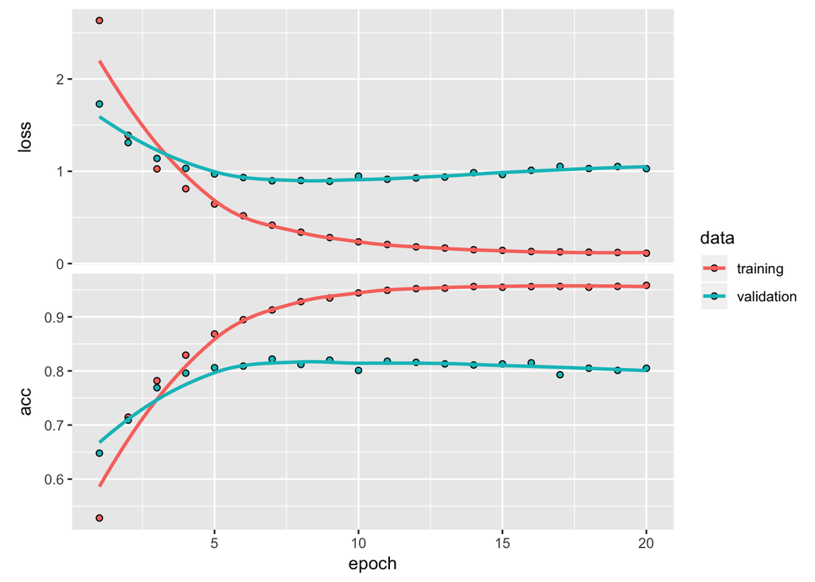

```r
# building the network
model <- keras_model_sequential() %>%
  layer_dense(units = 64, activation = "relu", input_shape = c(10000)) %>%
  layer_dense(units = 64, activation = "relu") %>%
  layer_dense(units = 46, activation = "softmax")
model %>% compile(
  optimizer = "rmsprop",
  loss = "categorical_crossentropy",
  metrics = c("accuracy")
)
# validate the approach
val_indices <- 1:1000
x_val <- x_train[val_indices,]
partial_x_train <- x_train[-val_indices,]
y_val <- one_hot_train_labels[val_indices,]
partial_y_train = one_hot_train_labels[-val_indices,]
# train the network for 20 epochs
history <- model %>% fit(
  partial_x_train,
  partial_y_train,
  epochs = 20,
  batch_size = 512,
  validation_data = list(x_val, y_val)
)
# display the loss and accuracy curves
plot(history)
```

```r
# train a new network from scratch for 9 epochs and then evaluate it on the test set
model <- keras_model_sequential() %>%
  layer_dense(units = 64, activation = "relu", input_shape = c(10000)) %>%
  layer_dense(units = 64, activation = "relu") %>%
  layer_dense(units = 46, activation = "softmax")

model %>% compile(
  optimizer = "rmsprop",
  loss = "categorical_crossentropy",
  metrics = c("accuracy")
)
history <- model %>% fit(
  partial_x_train,
  partial_y_train,
  epochs = 9,
  batch_size = 512,
  validation_data = list(x_val, y_val)
)
results <- model %>% evaluate(x_test, one_hot_test_labels)
results
```

```
## $loss
## [1] 0.9892578
##
## $acc
## [1] 0.7822796
```

```r
# compared with random baseline
test_labels_copy <- test_labels
test_labels_copy <- sample(test_labels_copy)
length(which(test_labels == test_labels_copy)) / length(test_labels)
```

```
## [1] 0.1878896
```

```r
# generating predictions on new data
predictions <- model %>% predict(x_test)
dim(predictions)
```

```
## [1] 2246   46
```

```r
sum(predictions[1,])
```

```
## [1] 1
```

```r
which.max(predictions[1,])
```

```
## [1] 4
```

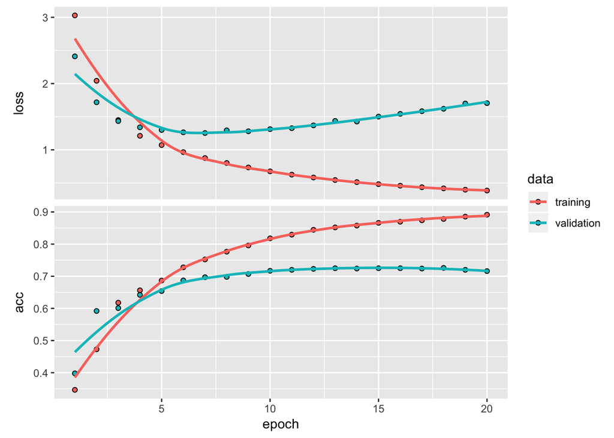

```r
# what happens if intermediate layers less than 46-dimensional
model <- keras_model_sequential() %>%
  layer_dense(units = 64, activation = "relu", input_shape = c(10000)) %>%
  layer_dense(units = 4, activation = "relu") %>%
  layer_dense(units = 46, activation = "softmax")

model %>% compile(
  optimizer = "rmsprop",
  loss = "categorical_crossentropy",
  metrics = c("accuracy")
)
history <- model %>% fit(
  partial_x_train,
  partial_y_train,
  epochs = 20,
  batch_size = 128,
  validation_data = list(x_val, y_val)
)
plot(history)
```

#### Exercise 4

Recreate the example provided in Section 3.6 (pg 76 - 83). See the [notebook](https://jjallaire.github.io/deep-learning-with-r-notebooks/notebooks/3.6-predicting-house-prices.nb.html) provided by the author.

```r
# load the data
library(keras)
dataset <- dataset_boston_housing()
c(c(train_data, train_targets), c(test_data, test_targets)) %<-% dataset
str(train_data)
```

```
##  num [1:404, 1:13] 1.2325 0.0218 4.8982 0.0396 3.6931 ...
```

```r
str(test_data)
```

```
##  num [1:102, 1:13] 18.0846 0.1233 0.055 1.2735 0.0715 ...
```

```r
str(train_targets)
```

```
##  num [1:404(1d)] 15.2 42.3 50 21.1 17.7 18.5 11.3 15.6 15.6 14.4 ...
```

```r
# preparing the data
mean <- apply(train_data, 2, mean)
std <- apply(train_data, 2, sd)
train_data <- scale(train_data, center = mean, scale = std)
test_data <- scale(test_data, center = mean, scale = std)
# build the network
build_model <- function() {
  model <- keras_model_sequential() %>%
    layer_dense(units = 64, activation = "relu",
                input_shape = dim(train_data)[[2]]) %>%
    layer_dense(units = 64, activation = "relu") %>%
    layer_dense(units = 1)

  model %>% compile(
    optimizer = "rmsprop",
    loss = "mse",
    metrics = c("mae")
  )
}
```

```r
# k-fold cross validation
k <- 4
indices <- sample(1:nrow(train_data))
folds <- cut(1:length(indices), breaks = k, labels = FALSE)
num_epochs <- 100
all_scores <- c()
for (i in 1:k) {
  cat("processing fold #", i, "\n")
  # Prepare the validation data: data from partition # k
  val_indices <- which(folds == i, arr.ind = TRUE)
  val_data <- train_data[val_indices,]
  val_targets <- train_targets[val_indices]

  # Prepare the training data: data from all other partitions
  partial_train_data <- train_data[-val_indices,]
  partial_train_targets <- train_targets[-val_indices]

  # Build the Keras model (already compiled)
  model <- build_model()

  # Train the model (in silent mode, verbose=0)
  model %>% fit(partial_train_data, partial_train_targets,
                epochs = num_epochs, batch_size = 1, verbose = 0)

  # Evaluate the model on the validation data
  results <- model %>% evaluate(val_data, val_targets, verbose = 0)
  all_scores <- c(all_scores, results$mean_absolute_error)
}
```

```
## processing fold # 1
## processing fold # 2
## processing fold # 3
## processing fold # 4
```

```r
all_scores
```

```
## [1] 1.886924 2.752614 2.482172 2.506959
```

```r
mean(all_scores)
```

```
## [1] 2.407167
```

```r
# try 500 epochs
# Some memory clean-up
k_clear_session()
num_epochs <- 500
all_mae_histories <- NULL
for (i in 1:k) {
  cat("processing fold #", i, "\n")

  # Prepare the validation data: data from partition # k
  val_indices <- which(folds == i, arr.ind = TRUE)
  val_data <- train_data[val_indices,]
  val_targets <- train_targets[val_indices]

  # Prepare the training data: data from all other partitions
  partial_train_data <- train_data[-val_indices,]
  partial_train_targets <- train_targets[-val_indices]

  # Build the Keras model (already compiled)
  model <- build_model()

  # Train the model (in silent mode, verbose=0)
  history <- model %>% fit(
    partial_train_data, partial_train_targets,
    validation_data = list(val_data, val_targets),
    epochs = num_epochs, batch_size = 1, verbose = 0
  )
  mae_history <- history$metrics$val_mean_absolute_error
  all_mae_histories <- rbind(all_mae_histories, mae_history)
}
```

```
## processing fold # 1
## processing fold # 2
## processing fold # 3
## processing fold # 4
```

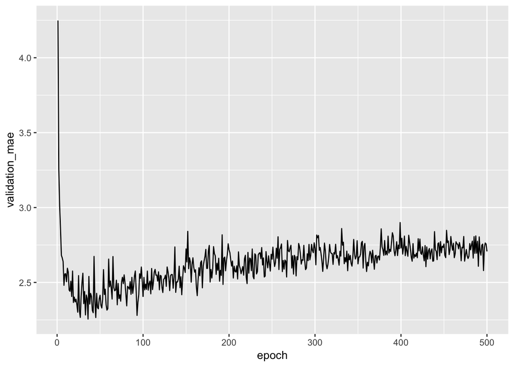

```r
# compute the average of the per-epoch MAE scores for all folds
average_mae_history <- data.frame(
  epoch = seq(1:ncol(all_mae_histories)),
  validation_mae = apply(all_mae_histories, 2, mean)
)
library(ggplot2)
ggplot(average_mae_history, aes(x = epoch, y = validation_mae)) + geom_line()
```

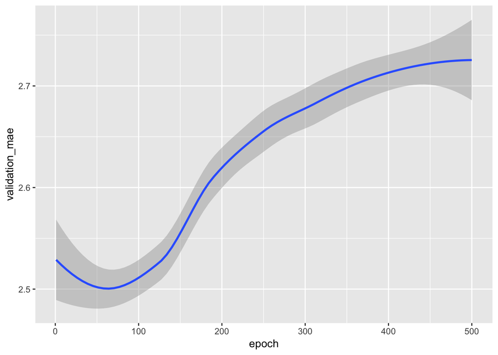

```r
# get a clearer picture
ggplot(average_mae_history, aes(x = epoch, y = validation_mae)) + geom_smooth()
```

```r
# Build the final model (epochs = 70)
model <- build_model()
# Train the model (in silent mode, verbose=0)
model %>% fit(train_data, train_targets,
                epochs = 70, batch_size = 1, verbose = 0)
# Evaluate the model on the testing data
results <- model %>% evaluate(test_data, test_targets, verbose = 0)
results
```

```
## $loss
## [1] 18.02649
##
## $mean_absolute_error
## [1] 2.575613
```